# Project: FBI NICS Firearm Background Check Data

Author : [Bijan Fallah](http://www.klimastatistik.de/about.html)

[figure not shown]

© FBI NICS

- Introduction
- Data Wrangling
- Exploratory Data Analysis
- Conclusions

## Introduction

"Mandated by the Brady Handgun Violence Prevention Act of 1993 and launched by the FBI on November 30, 1998, NICS is used by Federal Firearms Licensees (FFLs) to instantly determine whether a prospective buyer is eligible to buy firearms or explosives. Before ringing up the sale, cashiers call in a check to the FBI or to other designated agencies to ensure that each customer does not have a criminal record or isn’t otherwise ineligible to make a purchase. More than 100 million such checks have been made in the last decade, leading to more than 700,000 denials" (FBI NICS).

For additional information on the data check here: https://github.com/BuzzFeedNews/nics-firearm-background-checks/blob/master/README.md .

I prefer to think of my questions which I want to answer after cleaning the dataset. However, the questions which I could think of would be linked to the changes of statistic in time. How the behaviour have changed during the time? Another interesting aspect might be the geographical distribution of the gun data (i.e, how it is different between the states).

For me it is helpfull to think of what I can take from the data when I do some EDA on the data. Therefore please check for my key questions in the Exploratory Data Analysis section.

```python
# importing the libraries:
import numpy as np
import pandas as pd
import matplotlib.pyplot as plt
import seaborn as sb
import numpy as np
from mpl_toolkits.basemap import Basemap as Basemap
from matplotlib.colors import rgb2hex
from matplotlib.patches import Polygon
from matplotlib.colors import rgb2hex, Normalize
from matplotlib.cm import ScalarMappable
from matplotlib.colorbar import ColorbarBase
sb.set()
%matplotlib inline
```

## Data Wrangling

### General Properties

```python
# Load your data and print out a few lines. Perform operations to inspect data
#   types and look for instances of missing or possibly errant data.
data_dir = './ncis-and-census-data/'
# load the gun data file:

gun = pd.read_excel(data_dir+"gun_data.xlsx")
```

```python
# fast check of gun data :
print('shape of gun data = ', gun.shape)
gun.head()
```

```
shape of gun data =  (12485, 27)
```

|  | month | state | permit | permit_recheck | handgun | long_gun | other | multiple | admin | prepawn_handgun | ... | returned_other | rentals_handgun | rentals_long_gun | private_sale_handgun | private_sale_long_gun | private_sale_other | return_to_seller_handgun | return_to_seller_long_gun | return_to_seller_other | totals |
| --- | --- | --- | --- | --- | --- | --- | --- | --- | --- | --- | --- | --- | --- | --- | --- | --- | --- | --- | --- | --- | --- |
| 0 | 2017-09 | Alabama | 16717.0 | 0.0 | 5734.0 | 6320.0 | 221.0 | 317 | 0.0 | 15.0 | ... | 0.0 | 0.0 | 0.0 | 9.0 | 16.0 | 3.0 | 0.0 | 0.0 | 3.0 | 32019 |
| 1 | 2017-09 | Alaska | 209.0 | 2.0 | 2320.0 | 2930.0 | 219.0 | 160 | 0.0 | 5.0 | ... | 0.0 | 0.0 | 0.0 | 17.0 | 24.0 | 1.0 | 0.0 | 0.0 | 0.0 | 6303 |
| 2 | 2017-09 | Arizona | 5069.0 | 382.0 | 11063.0 | 7946.0 | 920.0 | 631 | 0.0 | 13.0 | ... | 0.0 | 0.0 | 0.0 | 38.0 | 12.0 | 2.0 | 0.0 | 0.0 | 0.0 | 28394 |
| 3 | 2017-09 | Arkansas | 2935.0 | 632.0 | 4347.0 | 6063.0 | 165.0 | 366 | 51.0 | 12.0 | ... | 0.0 | 0.0 | 0.0 | 13.0 | 23.0 | 0.0 | 0.0 | 2.0 | 1.0 | 17747 |
| 4 | 2017-09 | California | 57839.0 | 0.0 | 37165.0 | 24581.0 | 2984.0 | 0 | 0.0 | 0.0 | ... | 0.0 | 0.0 | 0.0 | 0.0 | 0.0 | 0.0 | 0.0 | 0.0 | 0.0 | 123506 |

5 rows × 27 columns

```python
# load the US census data file:
census = pd.read_csv(data_dir+"U.S. Census Data.csv")
# quicl checl of the data :
print('shape of census data = ', census.shape)
census.head(20)
```

```
shape of census data =  (85, 52)
```

|  | Fact | Fact Note | Alabama | Alaska | Arizona | Arkansas | California | Colorado | Connecticut | Delaware | ... | South Dakota | Tennessee | Texas | Utah | Vermont | Virginia | Washington | West Virginia | Wisconsin | Wyoming |
| --- | --- | --- | --- | --- | --- | --- | --- | --- | --- | --- | --- | --- | --- | --- | --- | --- | --- | --- | --- | --- | --- |
| 0 | Population estimates, July 1, 2016, (V2016) | NaN | 4,863,300 | 741,894 | 6,931,071 | 2,988,248 | 39,250,017 | 5,540,545 | 3,576,452 | 952,065 | ... | 865454 | 6651194 | 27,862,596 | 3,051,217 | 624,594 | 8,411,808 | 7,288,000 | 1,831,102 | 5,778,708 | 585,501 |
| 1 | Population estimates base, April 1, 2010, (V2... | NaN | 4,780,131 | 710,249 | 6,392,301 | 2,916,025 | 37,254,522 | 5,029,324 | 3,574,114 | 897,936 | ... | 814195 | 6346298 | 25,146,100 | 2,763,888 | 625,741 | 8,001,041 | 6,724,545 | 1,853,011 | 5,687,289 | 563,767 |
| 2 | Population, percent change - April 1, 2010 (es... | NaN | 1.70% | 4.50% | 8.40% | 2.50% | 5.40% | 10.20% | 0.10% | 6.00% | ... | 0.063 | 0.048 | 10.80% | 10.40% | -0.20% | 5.10% | 8.40% | -1.20% | 1.60% | 3.90% |
| 3 | Population, Census, April 1, 2010 | NaN | 4,779,736 | 710,231 | 6,392,017 | 2,915,918 | 37,253,956 | 5,029,196 | 3,574,097 | 897,934 | ... | 814180 | 6346105 | 25,145,561 | 2,763,885 | 625,741 | 8,001,024 | 6,724,540 | 1,852,994 | 5,686,986 | 563,626 |
| 4 | Persons under 5 years, percent, July 1, 2016, ... | NaN | 6.00% | 7.30% | 6.30% | 6.40% | 6.30% | 6.10% | 5.20% | 5.80% | ... | 0.071 | 0.061 | 7.20% | 8.30% | 4.90% | 6.10% | 6.20% | 5.50% | 5.80% | 6.50% |
| 5 | Persons under 5 years, percent, April 1, 2010 | NaN | 6.40% | 7.60% | 7.10% | 6.80% | 6.80% | 6.80% | 5.70% | 6.20% | ... | 0.073 | 0.064 | 7.70% | 9.50% | 5.10% | 6.40% | 6.50% | 5.60% | 6.30% | 7.10% |
| 6 | Persons under 18 years, percent, July 1, 2016,... | NaN | 22.60% | 25.20% | 23.50% | 23.60% | 23.20% | 22.80% | 21.10% | 21.50% | ... | 0.246 | 0.226 | 26.20% | 30.20% | 19.00% | 22.20% | 22.40% | 20.50% | 22.30% | 23.70% |
| 7 | Persons under 18 years, percent, April 1, 2010 | NaN | 23.70% | 26.40% | 25.50% | 24.40% | 25.00% | 24.40% | 22.90% | 22.90% | ... | 0.249 | 0.236 | 27.30% | 31.50% | 20.70% | 23.20% | 23.50% | 20.90% | 23.60% | 24.00% |
| 8 | Persons 65 years and over, percent, July 1, 2... | NaN | 16.10% | 10.40% | 16.90% | 16.30% | 13.60% | 13.40% | 16.10% | 17.50% | ... | 0.16 | 0.157 | 12.00% | 10.50% | 18.10% | 14.60% | 14.80% | 18.80% | 16.10% | 15.00% |
| 9 | Persons 65 years and over, percent, April 1, 2010 | NaN | 13.80% | 7.70% | 13.80% | 14.40% | 11.40% | 10.90% | 14.20% | 14.40% | ... | 0.143 | 0.134 | 10.30% | 9.00% | 14.60% | 12.20% | 12.30% | 16.00% | 13.70% | 12.40% |
| 10 | Female persons, percent, July 1, 2016, (V2016) | NaN | 51.60% | 47.70% | 50.30% | 50.90% | 50.30% | 49.70% | 51.20% | 51.60% | ... | 0.496 | 0.512 | 50.40% | 49.70% | 50.60% | 50.80% | 50.00% | 50.50% | 50.30% | 48.90% |
| 11 | Female persons, percent, April 1, 2010 | NaN | 51.50% | 48.00% | 50.30% | 50.90% | 50.30% | 49.90% | 51.30% | 51.60% | ... | 0.5 | 0.513 | 50.40% | 49.80% | 50.70% | 50.90% | 50.20% | 50.70% | 50.40% | 49.00% |
| 12 | White alone, percent, July 1, 2016, (V2016) | (a) | 69.30% | 66.10% | 83.30% | 79.40% | 72.70% | 87.50% | 80.60% | 70.10% | ... | 0.852 | 0.787 | 79.40% | 91.10% | 94.60% | 70.00% | 80.00% | 93.60% | 87.50% | 92.80% |
| 13 | Black or African American alone, percent, July... | (a) | 26.80% | 3.80% | 4.90% | 15.70% | 6.50% | 4.50% | 11.80% | 22.60% | ... | 0.02 | 0.171 | 12.60% | 1.40% | 1.30% | 19.80% | 4.10% | 3.60% | 6.60% | 1.30% |
| 14 | American Indian and Alaska Native alone, perce... | (a) | 0.70% | 15.20% | 5.40% | 1.00% | 1.70% | 1.60% | 0.50% | 0.60% | ... | 0.09 | 0.004 | 1.00% | 1.60% | 0.40% | 0.50% | 1.90% | 0.20% | 1.10% | 2.70% |
| 15 | Asian alone, percent, July 1, 2016, (V2016) | (a) | 1.40% | 6.30% | 3.40% | 1.60% | 14.80% | 3.30% | 4.70% | 4.00% | ... | 0.015 | 0.018 | 4.80% | 2.50% | 1.80% | 6.60% | 8.60% | 0.80% | 2.80% | 1.00% |
| 16 | Native Hawaiian and Other Pacific Islander alo... | (a) | 0.10% | 1.30% | 0.30% | 0.30% | 0.50% | 0.20% | 0.10% | 0.10% | ... | 0.001 | 0.001 | 0.10% | 1.00% | Z | 0.10% | 0.80% | Z | 0.10% | 0.10% |
| 17 | Two or More Races, percent, July 1, 2016, (V2... | NaN | 1.60% | 7.30% | 2.80% | 2.00% | 3.80% | 3.00% | 2.30% | 2.60% | ... | 0.023 | 0.019 | 1.90% | 2.50% | 1.90% | 2.90% | 4.60% | 1.70% | 1.90% | 2.10% |
| 18 | Hispanic or Latino, percent, July 1, 2016, (V... | (b) | 4.20% | 7.00% | 30.90% | 7.30% | 38.90% | 21.30% | 15.70% | 9.20% | ... | 0.037 | 0.052 | 39.10% | 13.80% | 1.90% | 9.10% | 12.40% | 1.50% | 6.70% | 10.00% |
| 19 | White alone, not Hispanic or Latino, percent, ... | NaN | 65.80% | 61.20% | 55.50% | 72.90% | 37.70% | 68.60% | 67.70% | 62.90% | ... | 0.825 | 0.742 | 42.60% | 78.80% | 93.10% | 62.40% | 69.50% | 92.30% | 81.70% | 84.10% |

20 rows × 52 columns

First I will focus on the gun data provioded here and maybe for the comparisons between the states I will use consus dataset as well.

```python
# first split the date from YYYY-MM to YYYY and MM
gun["year_int"] = gun["month"].apply(lambda x: int(x.split("-")[0]))
gun["month_int"] = gun["month"].apply(lambda x: int(x.split("-")[1]))
gun.head()
```

|  | month | state | permit | permit_recheck | handgun | long_gun | other | multiple | admin | prepawn_handgun | ... | rentals_long_gun | private_sale_handgun | private_sale_long_gun | private_sale_other | return_to_seller_handgun | return_to_seller_long_gun | return_to_seller_other | totals | year_int | month_int |
| --- | --- | --- | --- | --- | --- | --- | --- | --- | --- | --- | --- | --- | --- | --- | --- | --- | --- | --- | --- | --- | --- |
| 0 | 2017-09 | Alabama | 16717.0 | 0.0 | 5734.0 | 6320.0 | 221.0 | 317 | 0.0 | 15.0 | ... | 0.0 | 9.0 | 16.0 | 3.0 | 0.0 | 0.0 | 3.0 | 32019 | 2017 | 9 |
| 1 | 2017-09 | Alaska | 209.0 | 2.0 | 2320.0 | 2930.0 | 219.0 | 160 | 0.0 | 5.0 | ... | 0.0 | 17.0 | 24.0 | 1.0 | 0.0 | 0.0 | 0.0 | 6303 | 2017 | 9 |
| 2 | 2017-09 | Arizona | 5069.0 | 382.0 | 11063.0 | 7946.0 | 920.0 | 631 | 0.0 | 13.0 | ... | 0.0 | 38.0 | 12.0 | 2.0 | 0.0 | 0.0 | 0.0 | 28394 | 2017 | 9 |
| 3 | 2017-09 | Arkansas | 2935.0 | 632.0 | 4347.0 | 6063.0 | 165.0 | 366 | 51.0 | 12.0 | ... | 0.0 | 13.0 | 23.0 | 0.0 | 0.0 | 2.0 | 1.0 | 17747 | 2017 | 9 |
| 4 | 2017-09 | California | 57839.0 | 0.0 | 37165.0 | 24581.0 | 2984.0 | 0 | 0.0 | 0.0 | ... | 0.0 | 0.0 | 0.0 | 0.0 | 0.0 | 0.0 | 0.0 | 123506 | 2017 | 9 |

5 rows × 29 columns

```python
# check if the precent of missing values :
gun.isnull().sum() * 100 / len(gun)
```

```
month                         0.000000
state                         0.000000
permit                        0.192231
permit_recheck               91.189427
handgun                       0.160192
long_gun                      0.152183
other                        55.947137
multiple                      0.000000
admin                         0.184221
prepawn_handgun              15.562675
prepawn_long_gun             15.578694
prepawn_other                59.030837
redemption_handgun           15.538646
redemption_long_gun          15.546656
redemption_other             59.030837
returned_handgun             82.378855
returned_long_gun            82.819383
returned_other               85.462555
rentals_handgun              92.070485
rentals_long_gun             93.392070
private_sale_handgun         77.973568
private_sale_long_gun        77.973568
private_sale_other           77.973568
return_to_seller_handgun     80.176211
return_to_seller_long_gun    77.973568
return_to_seller_other       81.938326
totals                        0.000000
year_int                      0.000000
month_int                     0.000000
dtype: float64
```

```python
gun[gun['permit_recheck'].isna()].head()
```

|  | month | state | permit | permit_recheck | handgun | long_gun | other | multiple | admin | prepawn_handgun | ... | rentals_long_gun | private_sale_handgun | private_sale_long_gun | private_sale_other | return_to_seller_handgun | return_to_seller_long_gun | return_to_seller_other | totals | year_int | month_int |
| --- | --- | --- | --- | --- | --- | --- | --- | --- | --- | --- | --- | --- | --- | --- | --- | --- | --- | --- | --- | --- | --- |
| 1100 | 2016-01 | Alabama | 27242.0 | NaN | 25445.0 | 14785.0 | 1266.0 | 884 | 0.0 | 8.0 | ... | NaN | 16.0 | 15.0 | 2.0 | 0.0 | 1.0 | 0.0 | 73218 | 2016 | 1 |
| 1101 | 2016-01 | Alaska | 192.0 | NaN | 2859.0 | 2245.0 | 300.0 | 164 | 0.0 | 5.0 | ... | NaN | 2.0 | 0.0 | 0.0 | 0.0 | 1.0 | 0.0 | 6085 | 2016 | 1 |
| 1102 | 2016-01 | Arizona | 3898.0 | NaN | 15745.0 | 8512.0 | 1107.0 | 575 | 0.0 | 7.0 | ... | NaN | 10.0 | 9.0 | 2.0 | 4.0 | 2.0 | 0.0 | 31910 | 2016 | 1 |
| 1103 | 2016-01 | Arkansas | 3670.0 | NaN | 7954.0 | 5982.0 | 305.0 | 340 | 0.0 | 11.0 | ... | NaN | 3.0 | 6.0 | 1.0 | 1.0 | 0.0 | 0.0 | 20437 | 2016 | 1 |
| 1104 | 2016-01 | California | 127715.0 | NaN | 52139.0 | 32970.0 | 7054.0 | 0 | 0.0 | 0.0 | ... | NaN | 0.0 | 0.0 | 0.0 | 0.0 | 0.0 | 0.0 | 220912 | 2016 | 1 |

5 rows × 29 columns

As can be seen there are columns of data which have many nan values and it makes it really hard to impute them. Therefore, I decide to drop them if more than 50% of the rows are empty !

```python
# remove columns with nan couns more than 50%:
print(gun.isnull().sum() * 100 / len(gun))
drop_mask = gun.isnull().sum() * 100 / len(gun)> 50
gun.drop(columns=gun.columns[drop_mask.values], axis=1, inplace=True)
```

```
month                         0.000000
state                         0.000000
permit                        0.192231
permit_recheck               91.189427
handgun                       0.160192
long_gun                      0.152183
other                        55.947137
multiple                      0.000000
admin                         0.184221
prepawn_handgun              15.562675
prepawn_long_gun             15.578694
prepawn_other                59.030837
redemption_handgun           15.538646
redemption_long_gun          15.546656
redemption_other             59.030837
returned_handgun             82.378855
returned_long_gun            82.819383
returned_other               85.462555
rentals_handgun              92.070485
rentals_long_gun             93.392070
private_sale_handgun         77.973568
private_sale_long_gun        77.973568
private_sale_other           77.973568
return_to_seller_handgun     80.176211
return_to_seller_long_gun    77.973568
return_to_seller_other       81.938326
totals                        0.000000
year_int                      0.000000
month_int                     0.000000
dtype: float64
```

```python
# check if it worked:
print(gun.isnull().sum() * 100 / len(gun))
```

```
month                   0.000000
state                   0.000000
permit                  0.192231
handgun                 0.160192
long_gun                0.152183
multiple                0.000000
admin                   0.184221
prepawn_handgun        15.562675
prepawn_long_gun       15.578694
redemption_handgun     15.538646
redemption_long_gun    15.546656
totals                  0.000000
year_int                0.000000
month_int               0.000000
dtype: float64
```

```python
# Now I want to impute the nan values with the mean but before that I want to deep in more :
gun[gun['prepawn_handgun'].isnull()].head(5)
```

|  | month | state | permit | handgun | long_gun | multiple | admin | prepawn_handgun | prepawn_long_gun | redemption_handgun | redemption_long_gun | totals | year_int | month_int |
| --- | --- | --- | --- | --- | --- | --- | --- | --- | --- | --- | --- | --- | --- | --- |
| 7804 | 2005-12 | Virgin Islands | NaN | 22.0 | 1.0 | 0 | NaN | NaN | NaN | NaN | NaN | 23 | 2005 | 12 |
| 7859 | 2005-11 | Virgin Islands | NaN | 13.0 | 2.0 | 1 | NaN | NaN | NaN | NaN | NaN | 16 | 2005 | 11 |
| 7914 | 2005-10 | Virgin Islands | NaN | NaN | NaN | 0 | NaN | NaN | NaN | NaN | NaN | 0 | 2005 | 10 |
| 7969 | 2005-09 | Virgin Islands | NaN | NaN | NaN | 0 | NaN | NaN | NaN | NaN | NaN | 0 | 2005 | 9 |
| 8024 | 2005-08 | Virgin Islands | NaN | NaN | NaN | 0 | NaN | NaN | NaN | NaN | NaN | 0 | 2005 | 8 |

It can be seen that the following happen to be almost equaly Nan around 15%:

- prepawn_handgun 15.562675
- prepawn_long_gun 15.578694
- redemption_handgun 15.538646
- redemption_long_gun 15.546656

And more importantly the **permit** is my target variable and I do not want it to be NaN! And I do not want to impute it base on a regression model! So I drop all nans for **permit**:

```python
gun.dropna(subset=['permit'], inplace=True)
gun = gun.reset_index(drop=True)# reset index
gun[gun['prepawn_handgun'].isnull()].tail()
```

|  | month | state | permit | handgun | long_gun | multiple | admin | prepawn_handgun | prepawn_long_gun | redemption_handgun | redemption_long_gun | totals | year_int | month_int |
| --- | --- | --- | --- | --- | --- | --- | --- | --- | --- | --- | --- | --- | --- | --- |
| 12456 | 1998-11 | Virginia | 0.0 | 14.0 | 2.0 | 8 | 0.0 | NaN | NaN | NaN | NaN | 24 | 1998 | 11 |
| 12457 | 1998-11 | Washington | 1.0 | 65.0 | 286.0 | 8 | 1.0 | NaN | NaN | NaN | NaN | 361 | 1998 | 11 |
| 12458 | 1998-11 | West Virginia | 3.0 | 149.0 | 251.0 | 5 | 0.0 | NaN | NaN | NaN | NaN | 408 | 1998 | 11 |
| 12459 | 1998-11 | Wisconsin | 0.0 | 25.0 | 214.0 | 2 | 0.0 | NaN | NaN | NaN | NaN | 241 | 1998 | 11 |
| 12460 | 1998-11 | Wyoming | 8.0 | 45.0 | 49.0 | 5 | 0.0 | NaN | NaN | NaN | NaN | 107 | 1998 | 11 |

```python
# now check the nans again:
gun[gun['prepawn_handgun'].isnull()].head()
```

|  | month | state | permit | handgun | long_gun | multiple | admin | prepawn_handgun | prepawn_long_gun | redemption_handgun | redemption_long_gun | totals | year_int | month_int |
| --- | --- | --- | --- | --- | --- | --- | --- | --- | --- | --- | --- | --- | --- | --- |
| 8054 | 2005-07 | New Hampshire | 1238.0 | 964.0 | 1508.0 | 8 | 0.0 | NaN | 0.0 | 0.0 | 1.0 | 3719 | 2005 | 7 |
| 8689 | 2004-07 | Illinois | 25706.0 | 3663.0 | 5609.0 | 243 | 0.0 | NaN | 0.0 | 0.0 | 0.0 | 35221 | 2004 | 7 |
| 10152 | 2002-05 | Vermont | 0.0 | 482.0 | 869.0 | 28 | 0.0 | NaN | 0.0 | 1.0 | 1.0 | 1381 | 2002 | 5 |
| 10400 | 2001-12 | Mariana Islands | 0.0 | 0.0 | 0.0 | 0 | 0.0 | NaN | 0.0 | 0.0 | 0.0 | 0 | 2001 | 12 |
| 10544 | 2001-09 | Alabama | 0.0 | 7433.0 | 13656.0 | 318 | 0.0 | NaN | NaN | NaN | NaN | 21407 | 2001 | 9 |

I also want to drop the

- prepawn_handgun
- prepawn_long_gun
- redemption_handgun
- redemption_long_gun

as I found the following sentence in a pdf from the dataset [here](https://github.com/BuzzFeedNews/nics-firearm-background-checks/blob/master/pdfs/NICS_Firearm_Checks_-_Month_Year_by_State_Type.pdf) :

"The transaction types indicated in yellow on the chart are for background checks initiated by an officially-licensed Federal Firearms Licensee (FFL) or criminal justice/law enforcement agency prior to the issuance of a firearm-related permit or transfer " the yellow indicated variables are :

- permit
- permit recheck
- handgun
- longgun
- other
- multiple
- admin

Other—refers to frames, receivers, and other firearms that are neither handguns nor long guns (rifles or shotguns), such as firearms having a pistol grip that expel a shotgun shell, or National Firearms Act firearms, including silencers

Multiple (multiple types of firearms selected)

Now lets drop the columns I do not need :

```python
# drop the unwanted columns :
drop_list = ["prepawn_handgun", "prepawn_long_gun","redemption_handgun", "redemption_long_gun"]
gun.drop(columns=drop_list, axis=1, inplace=True)
gun.head()
```

|  | month | state | permit | handgun | long_gun | multiple | admin | totals | year_int | month_int |
| --- | --- | --- | --- | --- | --- | --- | --- | --- | --- | --- |
| 0 | 2017-09 | Alabama | 16717.0 | 5734.0 | 6320.0 | 317 | 0.0 | 32019 | 2017 | 9 |
| 1 | 2017-09 | Alaska | 209.0 | 2320.0 | 2930.0 | 160 | 0.0 | 6303 | 2017 | 9 |
| 2 | 2017-09 | Arizona | 5069.0 | 11063.0 | 7946.0 | 631 | 0.0 | 28394 | 2017 | 9 |
| 3 | 2017-09 | Arkansas | 2935.0 | 4347.0 | 6063.0 | 366 | 51.0 | 17747 | 2017 | 9 |
| 4 | 2017-09 | California | 57839.0 | 37165.0 | 24581.0 | 0 | 0.0 | 123506 | 2017 | 9 |

Now I will check if the type of the columns are okay and how I could impute the nan values :

```python
gun.isnull().sum()
```

```
month        0
state        0
permit       0
handgun      0
long_gun     0
multiple     0
admin        2
totals       0
year_int     0
month_int    0
dtype: int64
```

```python
# I will drop this two rows :
gun.dropna(inplace=True)
```

```python
# now check again :
gun.isnull().sum()
```

```
month        0
state        0
permit       0
handgun      0
long_gun     0
multiple     0
admin        0
totals       0
year_int     0
month_int    0
dtype: int64
```

```python
# check the types :
gun.info()
```

```
<class 'pandas.core.frame.DataFrame'>
Int64Index: 12459 entries, 0 to 12460
Data columns (total 10 columns):
month        12459 non-null object
state        12459 non-null object
permit       12459 non-null float64
handgun      12459 non-null float64
long_gun     12459 non-null float64
multiple     12459 non-null int64
admin        12459 non-null float64
totals       12459 non-null int64
year_int     12459 non-null int64
month_int    12459 non-null int64
dtypes: float64(4), int64(4), object(2)
memory usage: 1.0+ MB
```

Perfect! Now I have a clean data frame which I can use for my analysis !

## Exploratory Data Analysis

### Q1 : How did the Total NICS Background Check changed since Nov. 1998 ?

```python
# function for moving average:
# this might be used in my analysis :

def move_average(df, N = 3):

    rolling_mean = df.rolling(window=N).mean()

    return rolling_mean
```

I will use matplotzlib to plot the total checks

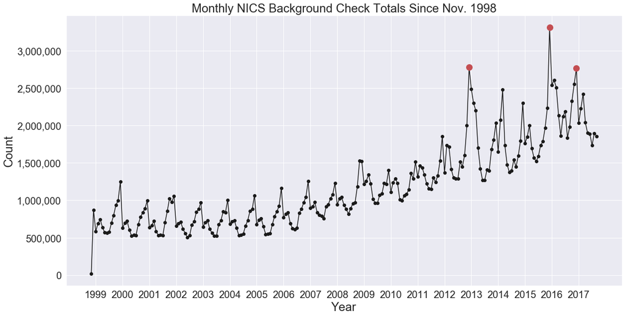

```python
plt.figure(figsize=(20,10))
totals = gun.groupby("month")["totals"].sum()
plt.plot(totals,'k-o')
#plt.plot(move_average(totals, N=12),'k-')
a= plt.axes()
tick_placement = pd.np.arange(2, len(totals), 12)
a.set_xticks(tick_placement);
a.set_xticklabels([ totals.index[i].split("-")[0] for i in tick_placement ], fontsize= 20)
a.set_yticklabels([ "{0:,.0f}".format(y) for y in a.get_yticks() ], fontsize=20)
plt.xlabel('Year', fontsize=24)
plt.ylabel('Count', fontsize=24)
a.set_title("Monthly NICS Background Check Totals Since Nov. 1998", fontsize=24);
# now color the 3 highest outliers:
tot = totals.copy()
tot.index = range(len(totals))
point = tot.index[tot == totals.nlargest(3)[0]]
plt.plot(point ,  totals.nlargest(3)[0],'ro', markersize=12)
point = tot.index[tot == totals.nlargest(3)[1]]
plt.plot(point ,  totals.nlargest(3)[1],'ro', markersize=12)
point = tot.index[tot == totals.nlargest(3)[2]]
plt.plot(point ,  totals.nlargest(3)[2],'ro', markersize=12)
```

*discussion* :

As can be seen the trend of total background check is positive with time. However, there exist several interesting patterns in this time-series:

1. Since year 2009 onwards the checks show a significant rise! Is this due to the President Obamas election ?
2. There exist 3 high outliers (red points in the upper figure)in tzhe time-series. I am really interested to know why they happend?

```python
# 3 highest dates :
totals.nlargest(3)
```

```
month
2015-12    3308199
2012-12    2776105
2016-12    2763115
Name: totals, dtype: int64
```

Interestng that the outliers happen all in **December** month!!!

### Q2 : Is there a monthly cycle in the total checks ?

[figure not shown]

```python
# Find the monthly cycle :
total_monthly = gun.groupby("month_int")["totals"].sum()
fig, ax = plt.subplots(figsize=(8,4))
plt.bar(range(1,13),total_monthly)
plt.xlabel('Month', fontsize=15)
plt.ylabel('Total Checks', fontsize=15)
plt.title('Monthly Mean of Total Background Checks', fontsize=20)
plt.show()
```

As can be seen from the plot there is a monthly cycle in the data with a peak at December !!!